# TIP

# ex 3.13

1. 1-P(전체 실패) = 1-(1-p)^n
2. choose(n,k) x P^k x (1-P)^(n-k)
3. p^n

## 확률 변수 (Random Variable)

- 전체 일어날 수 있는 사건 중에 특정 사건의 확률을 실수로 만들어주는 함수 ex) 동전을 n 번 던졌을때 앞면의 개수, output이 0~n 사이에 분포됨

### 이산 확률 변수

- 결과물이 유한함. 명목형 변수 포함

### 연속 확률 변수

- 결과물이 무한할 수 있음.

### 확률 함수

- p = f(확률 변수로 나오는 실수)
- 결과로 나온 실수를 확률(0 ~ 1) 사이에 매핑해주는 함수
- 2일차 3, 12/13page

### PMF (확률 질량 함수)

- 이산적으로 나온 히스토그램
- 이산적으로 나오지 않고, 밀도가 표현되면 확률 분표

## 기댓값

### 확률 변수 함수의 기댓값

## 분산

- 평균으로 부터 얼마나 흩어져 있는지

## 베르누이 확률 변수

- 결과가 두개로, 성공/실패로 나오는 확률변수

### 이항 확률 변수

- n번의 독립된 베르누이 확률을 시행
- 결과가 바이너리로 나옴 0,1

### 포아송분포

- 이항 확률에서 파생
- n번 실행하는게 아니라, n의 값이 불분명할때 사용
- n -> 무한으로 보내면 포아송분포가 나옴 (독립 변수 일때)
- 근접한 값을 찾는 것

### 기하 분포

- 독립된 베르누이 확률을 성공할때까지 실행

### 음의 이항 분포

- 독립된 베르누이 확률이 R번 성공할때까지 N번 실행
- N-1 까지 R-1 번 성공해야 되므로, 거기까지는 이항 확률 분포 + 마지막 실행
- 어떻게 응용할 수 있나? 유저가 평균적으로 n번의 접속 시도를 하다 실패하면 이탈한다고 할때?  
  비밀번호 틀리는 횟수가 n번 시도에서 R 이상이면 해킹 시도라 판단할때?

### 초기하 분포

- 어떤 특징? 비복원 추출 : 복원 추출이 아니므로 한번에 뽑아도 됨
- 언제 사용? 전체 중에서, 몇몇… 슬라이드 확인

# 연속 확률 변수

- 이산 변수는 특정 점에서 확률값을 가지기 때문에 Sum 으로 접근할 수 있음. = 질량 함수
- 연속 변수는 특정 점에서 확률값을 가지지 않고, 구간에서 확률값을 갖음. 특정 시점, 특정 위치에서의 확률값은 0에 수렴한다.  
  ex) 전구가 1년후에 정확히 고장날 확률. 1년 000.1초도 1년이라 인정 안한다면 확률값은 낮아짐
- 포인트에서는 확률값이 없기 때문에 >= 와 > 의 확률값이 같다. (=이 의미가 없다)
- 분산은 일반적인 식을 따름

## ## 확률 밀도 함수

## 누적 밀도 함수

- 밀도 함수를 누적 한것
- 지수 함수처럼 증가하는 그래프로 표현됨

## 연속 확률 분포

- 균일, 정규, 지수가 많이 쓰임

### 균일 분포

- 특정 구간에서 일어날 확률이 균일
- 특정 구간의 시작점 이전/ 끝 점 이후에는 발생 확률이 없음

#### 누적 분포 함수

- 균일 분포의 누적

### 정규 분포

- 중심극한 정리에서 파생
- 닫힌 형태(close form)이 없기 때문에, 정확한 값이 아닌 근사값을 구해야 함
- 근사값을 구하기위해 표준 정규분포로 변경

#### 표준 정규 분포

- 표준 정규 분포의 값은 공식이 없어서 바로 구하지 못하고, 표를 이용해서 찾음
- 표준 정규분포를 이용하여 데이터의 검증을 할 수 있음 (사건이 독립적이여야 하는가?)

### 이항 분포

- 히스토그램으로 표현되는 분포
- x축 단위 n을 0으로 수렴하게 하면 정규분포처럼 (혹은 밀도 함수) 표현할 수 있다

### 지수 분포

- 포아송 분포와 연관성이 있는 것 같다

### 감마 분포

### 베타 분포

# 관련된 R 함수들

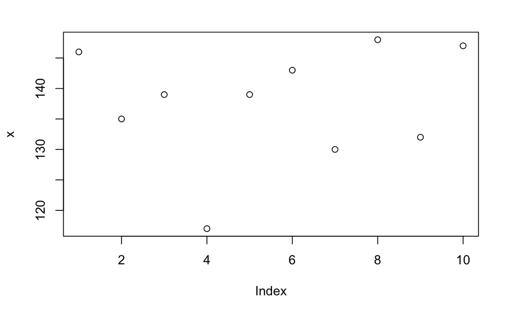

# 통계적 추정과 검정 (5일차 수업)

- 샘플을 가지고 모집단에 대한 가정을 검증하는 과정
- 샘플이 무작위로 추출되지 않으면, bias가 생김

## 생각의 과정

- 기획
- 가설을 세우는데, 구하고자 하는 가설과/ 대립 가설을 식으로 만듬
- 검정

## 검정 오류

- 1종 오류 (알파, 유의 수준) 귀무 가설이 옳은데 기각하는 경우
- 2종 오류 (베타) 실제로 거짓인 귀무 가설을 받아드리는 경우
- 검정 과정에서는 알파/ 베타의 확률을 줄이는 방향으로 진행